# Assignment 05

Author

Benjamin Reese

## Installing Packages Needed For Analysis

```r
## Packages
library(tidyverse)
library(stringr)
library(readr)
library(lubridate)
library(sf)
library(tigris)
library(patchwork)
library(httr)
library(jsonlite)
library(testthat)
```

## 1. Data Cleaning and Loading

```r
## Data Loading
crimes <- read_csv("data/crimes-reduced.csv", col_types = cols(Latitude = col_character(),
        Longitude = col_character()))

## Data Cleaning
crimes <- crimes %>%
  rename_all(funs(str_to_lower(.) %>% ## changing to lowercase
                    str_replace_all(., '\\s','_') ## removing spaces
                  )
  )
```

## 2. Filtering Data

```r
## Formatting date variable, filtering out NAs, and only including homicides
crimes_lim <- crimes %>%
  mutate(date = as_date(mdy_hms(date, tz= "America/Chicago"))) %>%
  filter(primary_type == "HOMICIDE",
         !is.na(longitude),
         !is.na(latitude),
         !is.na(date),
         date  >= today() - years(10) ## Past 10 Years, should update
)

## Showing the lower_case and removed spaces
crimes_lim
```

```
# A tibble: 5,725 × 10
         id date       primary_…¹ arrest x_coo…² y_coo…³ commu…⁴ latit…⁵ longi…⁶
      <dbl> <date>     <chr>      <lgl>    <dbl>   <dbl>   <dbl> <chr>   <chr>
 1 10156667 2015-07-18 HOMICIDE   TRUE   1175712 1902172      32 41.886… -87.63…
 2 10164471 2015-07-23 HOMICIDE   TRUE   1138403 1922795      15 41.944… -87.76…
 3    22032 2015-08-15 HOMICIDE   TRUE   1152321 1902190      27 41.887… -87.71…
 4 10222837 2015-09-03 HOMICIDE   TRUE   1168593 1938326      77 41.986… -87.65…
 5 10372192 2015-12-12 HOMICIDE   TRUE   1170546 1857571      68 41.764… -87.65…
 6 11823422 2019-08-10 HOMICIDE   TRUE   1180077 1864658      42 41.783… -87.61…
 7    24568 2019-05-29 HOMICIDE   FALSE  1179224 1829773      49 41.688… -87.61…
 8 10569766 2016-06-21 HOMICIDE   TRUE   1177193 1877179      38 41.818… -87.62…
 9 10586888 2016-07-05 HOMICIDE   TRUE   1158439 1875197      58 41.813… -87.69…
10    25665 2020-12-11 HOMICIDE   TRUE   1178967 1868946      40 41.795… -87.61…
# … with 5,715 more rows, 1 more variable: location <chr>, and abbreviated
#   variable names ¹primary_type, ²x_coordinate, ³y_coordinate,
#   ⁴community_area, ⁵latitude, ⁶longitude
# ℹ Use `print(n = ...)` to see more rows, and `colnames()` to see all variable names
```

### Testing the Filtering

```r
## Testing
table(year(crimes_lim$date))
```

```
2012 2013 2014 2015 2016 2017 2018 2019 2020 2021 2022
  87  431  429  502  790  676  601  508  794  808   99
```

```r
min(crimes_lim$date)
```

```
[1] "2012-10-19"
```

## 3. Convert Lon/Lat to Points Geometry And Making Map

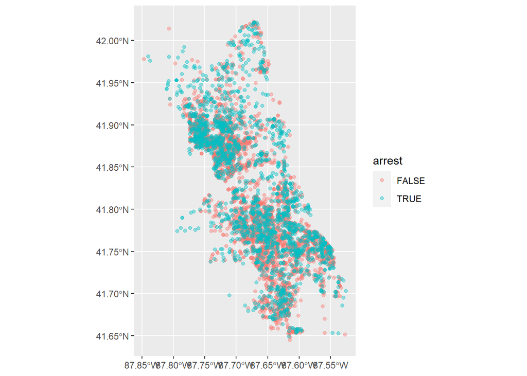

```r
## Converting lat and lon and coloring dots by arrest
crimes_lim %>%
  st_as_sf(coords = c("longitude", "latitude")) %>%
  st_set_crs(value = 4326) %>%
  ggplot() +
  geom_sf(aes(color=arrest), alpha=.4) ## using alpha for transparency
```

## 4. Load Census Tracts, Perform a Spatial Join, and Create Choropleth

```r
## Reading in shapefile
chi_shape <- st_read("data/Boundaries - Census Tracts - 2010/geo_export_098913a2-eb78-48e6-944e-bdaaf19b94f6.shp")
```

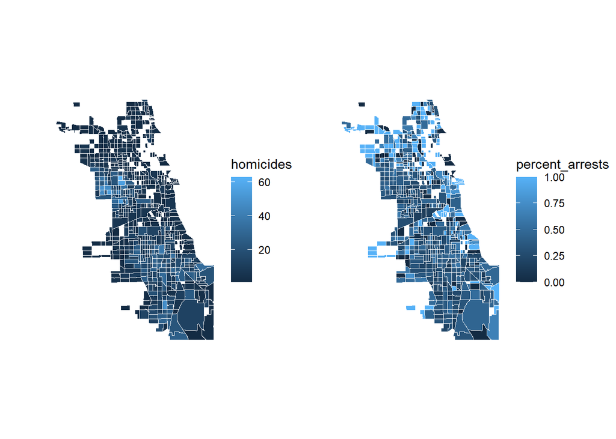

```r
## Selecting only geoid10 and geometry
chi_shape <- chi_shape %>%
  select(geoid10, geometry)

## Setting crimes_lim coords
crimes_lim <- crimes_lim %>%
  st_as_sf(coords = c("longitude", "latitude")) %>%
  st_set_crs(value = 4326)

## Transforming crimes_lim
crimes_lim <- st_transform(crimes_lim, crs = 4326)

## Setting chi_shape crs
chi_shape <- st_transform(chi_shape, crs = 4326)

## Joining the shape file to crime data
chi_joins <- st_join(chi_shape, crimes_lim)

## Creating merged_chi_agg
merged_chi_agg <- chi_joins %>%
  group_by(geoid10) %>%
  summarize(homicides = sum(primary_type=="HOMICIDE"),
            percent_arrests = mean(arrest))

## Homicide Map
chi_map1 <- merged_chi_agg %>%
  ggplot(aes(fill=homicides)) +
  geom_sf(color="white", lwd=.1) +
  scale_fill_gradient(guide="colorbar", na.value="white") +
  theme_void()

## Arrests Percent Map
chi_map2 <- merged_chi_agg %>%
  ggplot(aes(fill=percent_arrests)) +
  geom_sf(color="white", lwd=.1) +
  scale_fill_gradient(guide="colorbar", na.value="white") +
  theme_void()

## Using patchwork to put the maps together
chi_map1 + chi_map2
```

### Short Paragraph About Maps

The Central-Northwestern part of the city has the most homicides, as shown in the left map above. There are also some clusters of high homicide Census tracts around South and South Central Chicago. The other areas of the city do not have as many homicides. Homicides in Chicago seem to be quite geographically clustered and many Census tracts have few homicides. Perhaps surprisingly, the areas of Chicago with relatively fewer homicides have higher arrest rates, meaning homicides that occur in areas where homicides are more unusual are more likely to end in an arrest than killings in the Census tracts that have high amounts of homicides. In sum, there are pockets of high homicide areas in Chicago where a smaller proportion of the homicides result in an arrest, while the low homicide areas are more likely to make an arrest in connection to the homicide.

## 5. Using the Census API

I already have my census API key installed from an in class exercise, so I will just display the key.

```r
## tidycensus package loading
library(tidycensus)

## Showing my key
Sys.getenv("CENSUS_API_KEY")
```

```
[1] "ef3e91b4b57955de6fbf3f957341452734d1b79a"
```

```r
## Loading in Variables with tidycensus
chi_stats <- get_acs(
  geography = "tract",
  variables = c("B19013_001", "B15003_022", "B17017_002"),
  state = "Illinois",
  county = "Cook County",
  geometry = TRUE,
  output = "wide",
  year = 2019,
  progress = FALSE
)

## URL method
url <-
  "https://api.census.gov/data/2019/acs/acs5?get=B19013_001E,B15003_022E,B17017_002E&for=tract:*&in=county:031&in=state:17&key=ef3e91b4b57955de6fbf3f957341452734d1b79a"

## Using url to make request from API
acs_json <- GET(url = url)

## Checking status
http_status(acs_json)
```

```
$category
[1] "Success"

$reason
[1] "OK"

$message
[1] "Success: (200) OK"
```

```r
## Making a text string
acs_json <- content(acs_json, as = "text")

## Creating a character matrix
acs_matrix <- fromJSON(acs_json)

## Turning into tibble
acs_data <- as_tibble(acs_matrix[2:nrow(acs_matrix), ], .name_repair = "minimal")

## Adding names
names(acs_data) <- acs_matrix[1,]
```

### Now testing the equivalencies

```r
## Formatting the tidycensus data for test
chi_test <- as_tibble(chi_stats) %>%
  select(B19013_001E, B15003_022E, B17017_002E) %>%
  arrange(desc(B19013_001E))

## Forming the url method data for test
acs_data_test <- acs_data %>%
  select(B19013_001E, B15003_022E, B17017_002E) %>%
  mutate(B19013_001E = as.numeric(B19013_001E),
         B15003_022E = as.numeric(B15003_022E),
         B17017_002E = as.numeric(B17017_002E)) %>%
  mutate_all(~replace(., . == -666666666, NA)) %>%
  arrange(desc(B19013_001E))

## Running the test with all_equal
all_equal(acs_data_test, chi_test)
```

```
[1] TRUE
```

```r
## Using test_that
test_that("if tibbles are equal", {
           expect_equivalent(all_equal(chi_test, acs_data_test), TRUE)
})
```

```
Test passed 🥳
```